# Torneo de Karate WKF — Guía de uso

Del alta del campeonato a la mesa con Video Review · micancha.com.py · actualizada el 8 de noviembre de 2026

## 1. Estado del sistema

Flujo probado de punta a punta en producción con el torneo «XIII Torneo Internacional Seigokan [PRUEBA]»: 4 categorías de la carta de invitación, 5 dojos (Paraguay, Argentina, Brasil y Chile) y 20 atletas ficticios.

| Etapa | Estado | Qué hace |
| --- | --- | --- |
| Crear campeonato | Funciona | Pide nombre, formato WKF, fechas, sede y categorías con sus divisiones. |
| Datos, sede y visibilidad | Funciona | Se guardan solos; el mapa respeta el nombre del lugar escrito. |
| Inscripción de dojos y atletas | Funciona | Dojos con estado «Pendiente de confirmar» / «Confirmado». |
| Check-in y báscula WKF | Funciona | Peso con tolerancia ±1 kg; si excede, descalifica y da walkover al rival. |
| Agrupación WKF | Funciona | Ubica a cada atleta en su división por género, edad, modalidad y peso. |
| Sorteo de llaves | Funciona | Llave por división con byes, compañeros de dojo separados y tatami fijo. |
| Mesa Kumite y Kata | Funciona | Kumite por puntos; Kata por banderas. El ganador avanza solo en la llave. |
| Marcador TV y Video Review | Funciona | Sincronizados en tiempo real; el VR exige sesión iniciada. |

## 2. Crear el campeonato

### 1 Nuevo campeonato con categorías

Con la cuenta del organizador: **Mis campeonatos** → + Nuevo Campeonato → **Campeonato con categorías**. El administrador puede entrar como organizador desde `/admin` → **Organizadores** → clic en la fila.

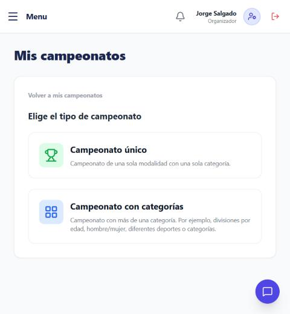

### 2 Datos del campeonato

Nombre, deporte **Karate**, formato **Sistema Oficial WKF**, **fecha de inicio y fin** y **sede**. Luego, con Agregar Categoría y Nueva División, cargar las categorías de la carta de invitación.

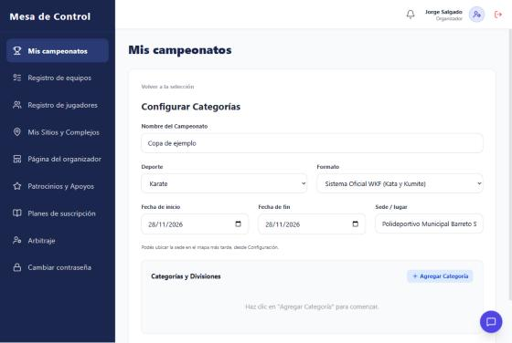

**Cómo nombrar las categorías para que la agrupación automática funcione:** incluir la **modalidad** (Kata / Kumite), el **género** (Femenino / Masculino) y la **edad** («14-15 años», «Cadete», «Junior», «Senior», «Sub-21»); el **peso** va en la división («-54 kg», «+75 kg»). Ejemplos: *Kumite Cadete Femenino (14-15 años)* → *-54 kg* · *Kata Senior Femenino* → *Oficial WKF*.

## 3. Configurar datos, sede e inscripción

### 3 Configuración

En el campeonato: Gestionar → menú **Configuración**. Todo el torneo se maneja desde aquí; los cambios se guardan solos.

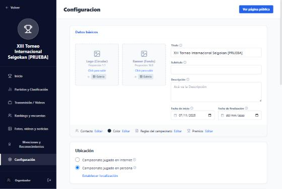

### 4 Ubicar la sede en el mapa

**Ubicación** → «Campeonato jugado en persona» → Establecer localización: buscar la ciudad o hacer clic en el mapa y Guardar. El nombre del lugar que escribiste se mantiene.

[figure not shown]

### 5 Modalidad «Por atleta» y visibilidad

**Modalidad de Inscripción** → **Por atleta** (cada atleta de un dojo puede ir a una categoría distinta). En **Divulgación**, «Campeonato privado» apagado = torneo público.

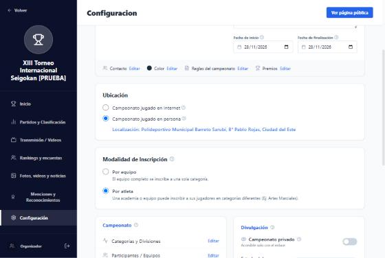

## 4. Inscribir dojos y atletas

### 6 Dojos y atletas

Configuración → **Participantes / Equipos**: escribir el nombre del dojo y Añadir. Para cargar atletas, clic en el dojo (o en su ícono de atletas). En la ficha: nombre, género, formato (*Combate* = Kumite, *Formas* = Kata), fecha de nacimiento y Añadir. Completar entrenador, marcar **Inscripción Confirmada** y Guardar.

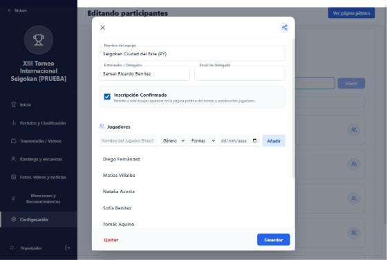

Los dojos sin confirmar se ven como «⏳ Pendiente de confirmar»; al confirmar, «✓ Confirmado».

## 5. Check-in y pesaje oficial

### 7 Check-in

Configuración → **Check-in (Pesaje)** → Hacer Check-in: peso, estatura (opcional) y **Pago Confirmado**.

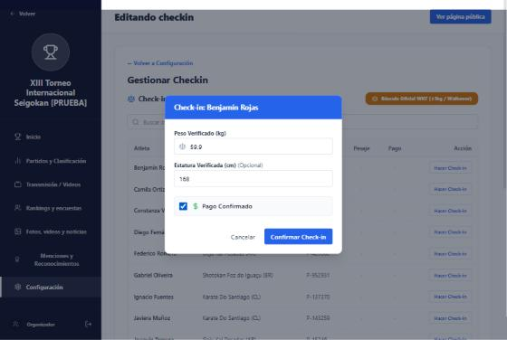

### 8 Báscula oficial WKF (±1 kg)

En **Llaves / Combates** → Pesaje Oficial (±1kg / Walkover). La báscula toma el **límite de la división** del atleta (por eso conviene usarla después de *Agrupar*) y solo ofrece los pesos de este torneo. Si el peso supera el límite + 1 kg, el atleta queda **descalificado** y su rival **avanza por walkover**. Si el atleta todavía no tiene división, la báscula pide elegir el límite antes de evaluar.

[figure not shown]

## 6. Agrupación y sorteo de llaves

### 9 Agrupar por WKF

Configuración → **Llaves / Combates (Programación)** → Agrupar por WKF. Cada atleta queda en su división según género, edad a la fecha del torneo, modalidad y peso del check-in. Los que no encajan aparecen con el motivo.

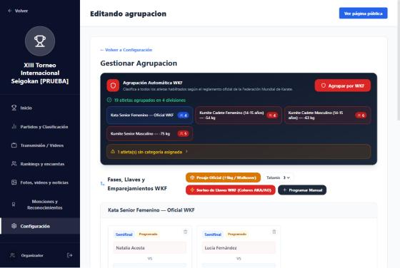

19 atletas en 4 divisiones. Sofía Benítez (55,8 kg) queda fuera de −54 kg por peso excedido.

### 10 Sorteo de llaves

Elegir la cantidad de **Tatamis** y pulsar Sorteo de Llaves WKF. Se arma una llave de eliminación directa por división:

- **Byes** automáticos cuando la cantidad de atletas no es potencia de 2: el atleta pasa directo a la ronda siguiente.
- **Compañeros de dojo separados** en la primera ronda.
- **Tatami fijo** por división, repartiendo la carga entre tatamis.
- AKA (rojo) arriba, AO (azul) abajo.

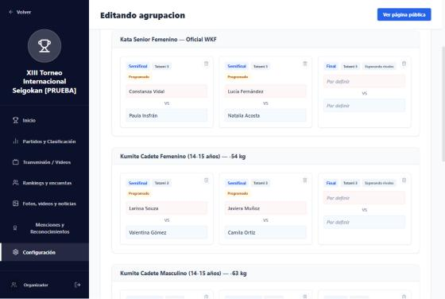

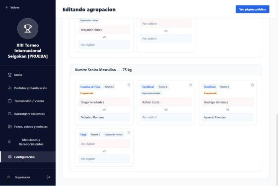

Senior −75 kg (5 atletas): un cuarto de final, tres byes y semifinales listas.

Repetir el sorteo **no duplica** llaves: las divisiones que ya tienen llave se respetan. Programar Manual sigue disponible para casos especiales (filtra atletas por división y pide tatami).

## 7. Disputar los combates

### 11 Mesa de control

`https://micancha.com.py/torneos/<ID>/arbitraje/combate?tatami=1` — arriba se elige **tatami** y **combate**; solo aparecen los combates con ambos rivales definidos, en orden de ronda. Los botones Marcador TV, Cámara y Juez VR abren cada estación conectada a ese combate.

[figure not shown]

### 12 Kumite

HAJIME arranca el reloj; +1 Yuko, +2 Waza-ari y +3 Ippon puntúan; Senshu se asigna solo al primer punto. Al terminar, estado **FINALIZADO**. El ganador (por puntos o, en empate, por Senshu, Ippon y Waza-ari) **pasa solo al combate siguiente** de la llave.

[figure not shown]

Marcador TV sincronizado; al cerrar el combate muestra «FINALIZADO».

### 13 Kata

Los combates de divisiones de Kata se abren automáticamente con la **mesa de Kata**: votación por banderas (3, 5 o 7 jueces) o calificación decimal. Guardar calificación oficial registra el ganador y lo pasa a la ronda siguiente.

[figure not shown]

## 8. Video Review

### 14 Pedido del coach

La mesa pulsa VR Card: DISP. del lado del coach y elige la **técnica reclamada** (Yuko, Waza-ari, Ippon o Senshu). El reloj se pausa, la TV muestra «VIDEO REVIEW» y la tarjeta queda «EN REVISIÓN».

[figure not shown]

### 15 Veredicto del Juez VR

La tablet recibe el pedido con la técnica y una cuenta regresiva de 30 s. Botones: +1/+2/+3/SENSHU (aceptado: suma y el coach conserva la tarjeta), ✗ RECHAZADO (pierde la tarjeta) y 👁 MIENAI (no visible: conserva la tarjeta). La mesa reanuda con Hajime.

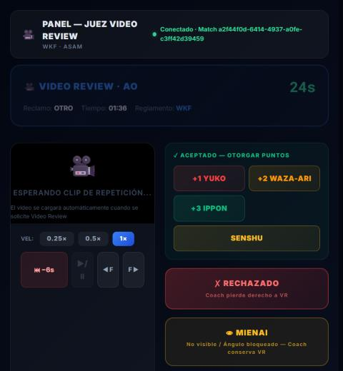

**Importante:** la tablet del juez y la cámara deben tener **sesión iniciada** con la cuenta del organizador (micancha.com.py/torneos/login). Sin sesión, la tablet avisa y no registra el veredicto. El Marcador TV no necesita sesión.

## 9. Checklist del día del torneo

1. Inscripciones cerradas y dojos **confirmados**.
2. Check-in de todos los atletas (peso y pago).
3. Agrupar por WKF y revisar la lista «sin categoría».
4. Báscula oficial para los casos dudosos (walkover automático si excede).
5. Sorteo de Llaves WKF con la cantidad de tatamis disponible.
6. En cada tatami: notebook con la mesa, TV con el marcador, tablet del Juez VR y celular con la cámara — **todos con sesión iniciada** salvo la TV.
7. Prueba rápida de la cámara con «⚡ Disparar Replay Ahora (Prueba)».